# Intro2R Solutions for BU Coding Hour

Rachel Wright

6/14/2018

# Before you do anything

Make a directory on your computer

(BONUS: do this at the command line)

Set your working directory to that directory

```r
setwd("~/Documents/daviesLab/codingHour/")
```

# PART 1: Analyzing Donut Consumption

Create a vector of 20 random numbers ranging from 1 to 10. Call it `donuts_week1`.

```r
set.seed(1)
donuts_week1 <- sample(1:10, 20, replace=T)
```

Create a vector of 20 random numbers ranging from 5 to 15. Call it `donuts_week2`.

```r
set.seed(1) # <----- you have to "set the seed" every time you call a random operation
donuts_week2 <- sample(5:15, 20, replace = T)
```

Summarize the `donuts_week1` and `donuts_week2` objects using the `summary` function

```r
summary(donuts_week1)
```

```
##    Min. 1st Qu.  Median    Mean 3rd Qu.    Max.
##    1.00    3.75    6.50    5.95    8.00   10.00
```

```r
summary(donuts_week2)
```

```
##    Min. 1st Qu.  Median    Mean 3rd Qu.    Max.
##    5.00    8.50   11.00   10.55   13.00   15.00
```

What is the data type of the `donuts_week2` and `donuts_week1` objects? There are lots of ways to do it…

```r
typeof(donuts_week1)
```

```
## [1] "integer"
```

```r
typeof(donuts_week2)
```

```
## [1] "integer"
```

```r
class(donuts_week1)
```

```
## [1] "integer"
```

```r
class(donuts_week2)
```

```
## [1] "integer"
```

```r
str(donuts_week2)
```

```
##  int [1:20] 7 9 11 14 7 14 15 12 11 5 ...
```

```r
str(donuts_week1)
```

```
##  int [1:20] 3 4 6 10 3 9 10 7 7 1 ...
```

Make a histogram of `donuts_week1`. Title the histogram “Donut Consumption at Peer Coding Hour”. Call the x-axis “Number of Donuts Eaten by Peer Coders”.

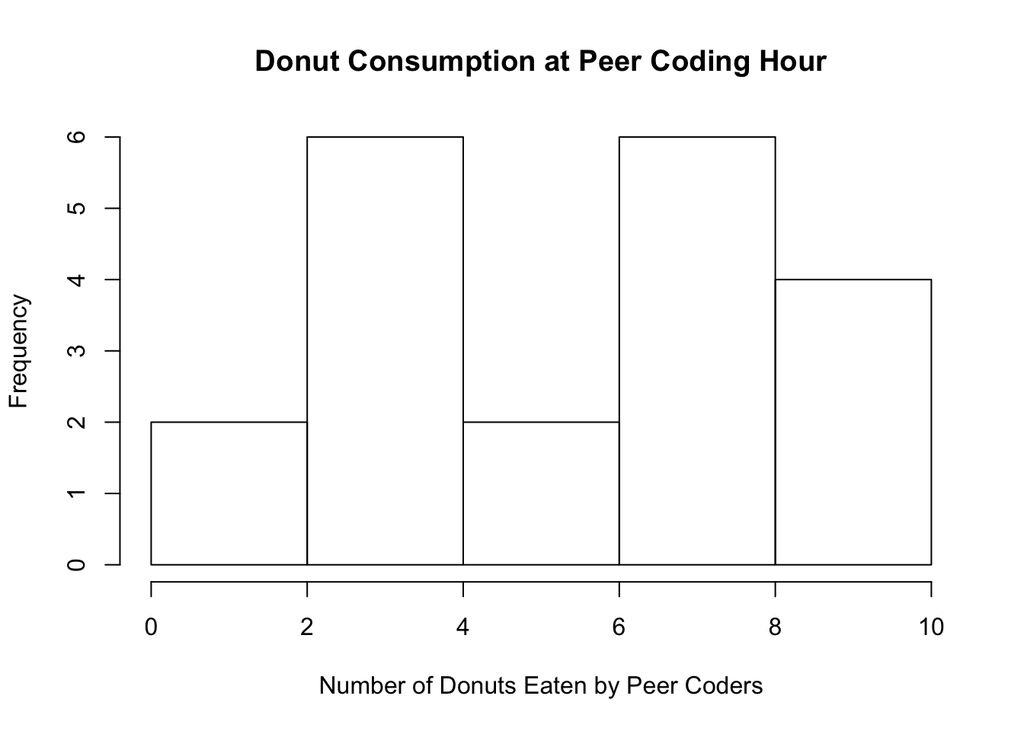

```r
hist(donuts_week1, main = "Donut Consumption at Peer Coding Hour", xlab = "Number of Donuts Eaten by Peer Coders")
```

Plot a histogram of `donuts_week2` on top of a histogram of `donuts_week1`. HINT: you may want to play around with colors here. You’ll definitely need to adjust the axes to see all of the data. BONUS: add a legend to the figure to discrimate between the histograms

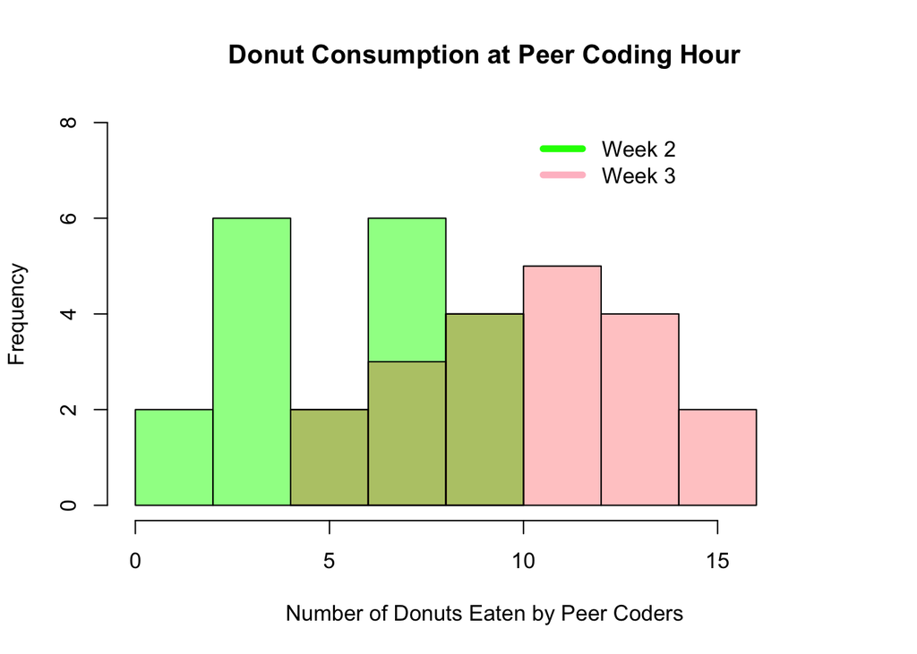

```r
hist(donuts_week1, main = "Donut Consumption at Peer Coding Hour", xlab = "Number of Donuts Eaten by Peer Coders", xlim = c(0,18), ylim = c(0,8), col=rgb(0,1,0,0.5))
hist(donuts_week2, col=rgb(1,0,0,0.25), add = T)
legend(x = 10, y = 8, c("Week 2", "Week 3"), col=c("green", "pink"), lwd = 5, bty = "n")
```

Use a t-test to determine if there is a significant difference in the number of donuts consumed on week 1 vs. week 2

```r
t.test(donuts_week1, donuts_week2, paired = F)
```

```
##
##  Welch Two Sample t-test
##
## data:  donuts_week1 and donuts_week2
## t = -4.922, df = 37.768, p-value = 1.716e-05
## alternative hypothesis: true difference in means is not equal to 0
## 95 percent confidence interval:
##  -6.492319 -2.707681
## sample estimates:
## mean of x mean of y
##      5.95     10.55
```

# PART 2: Relationship between Donut and Coffee Consumption

Create a vector of 20 random numbers ranging from 1 to 10. Call it `coffee_week1`.

```r
set.seed(1)
coffee_week1 <- sample(1:10, 20, replace=T)
```

Examine this data in some way. Coders choice!

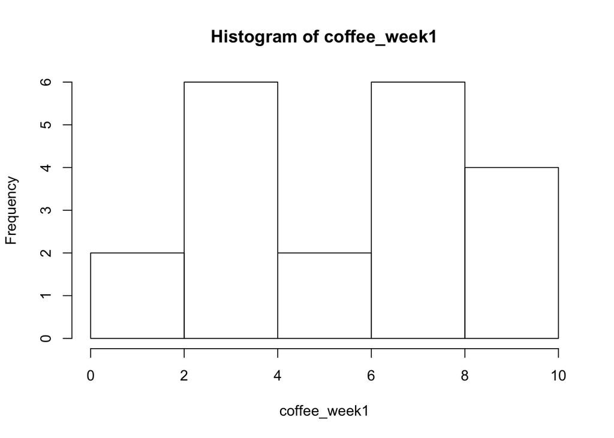

```r
hist(coffee_week1)
```

```r
summary(coffee_week1)
```

```
##    Min. 1st Qu.  Median    Mean 3rd Qu.    Max.
##    1.00    3.75    6.50    5.95    8.00   10.00
```

```r
str(coffee_week1)
```

```
##  int [1:20] 3 4 6 10 3 9 10 7 7 1 ...
```

```r
table(coffee_week1)
```

```
## coffee_week1
##  1  2  3  4  5  6  7  8  9 10
##  1  1  3  3  1  1  3  3  1  3
```

```r
max(coffee_week1)
```

```
## [1] 10
```

```r
min(coffee_week1)
```

```
## [1] 1
```

Create a data frame called `coffee_donut_data` that has one column for `donuts_week1` and one column for `coffee_week1`

```r
coffee_donut_data <- data.frame(donuts_week1, coffee_week1)
```

Enter a line of code that tells you what type of object `coffee_donut_data` is and what type of data it contains (integers? characters?)

```r
str(coffee_donut_data)
```

```
## 'data.frame':    20 obs. of  2 variables:
##  $ donuts_week1: int  3 4 6 10 3 9 10 7 7 1 ...
##  $ coffee_week1: int  3 4 6 10 3 9 10 7 7 1 ...
```

Plot donuts consumed on the x-axis and coffee consumed on the y-axis. Give the plot a name. Label the x- and y-axes.

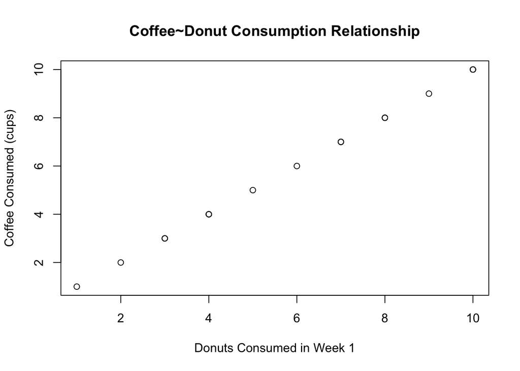

```r
plot(coffee_week1~donuts_week1,data=coffee_donut_data, main = "Coffee~Donut Consumption Relationship", ylab = "Coffee Consumed (cups)", xlab = "Donuts Consumed in Week 1")
```

Use a linear model to test the relationship between coffee and donut consumption. Save the results to a variable called `lm_coffee_donuts`.

```r
lm_coffee_donuts <- lm(coffee_week1~donuts_week1,data=coffee_donut_data)
```

Summarize `lm_coffee_donuts`

```r
summary(lm_coffee_donuts)
```

```
##
## Call:
## lm(formula = coffee_week1 ~ donuts_week1, data = coffee_donut_data)
##
## Residuals:
##        Min         1Q     Median         3Q        Max
## -2.521e-15  2.789e-17  9.767e-17  1.326e-16  4.942e-16
##
## Coefficients:
##                Estimate Std. Error    t value Pr(>|t|)
## (Intercept)  -1.589e-15  3.349e-16 -4.744e+00 0.000162 ***
## donuts_week1  1.000e+00  5.105e-17  1.959e+16  < 2e-16 ***
## ---
## Signif. codes:  0 '***' 0.001 '**' 0.01 '*' 0.05 '.' 0.1 ' ' 1
##
## Residual standard error: 6.313e-16 on 18 degrees of freedom
## Multiple R-squared:      1,  Adjusted R-squared:      1
## F-statistic: 3.838e+32 on 1 and 18 DF,  p-value: < 2.2e-16
```

Add a regression line to the plot you made earlier using this linear model.

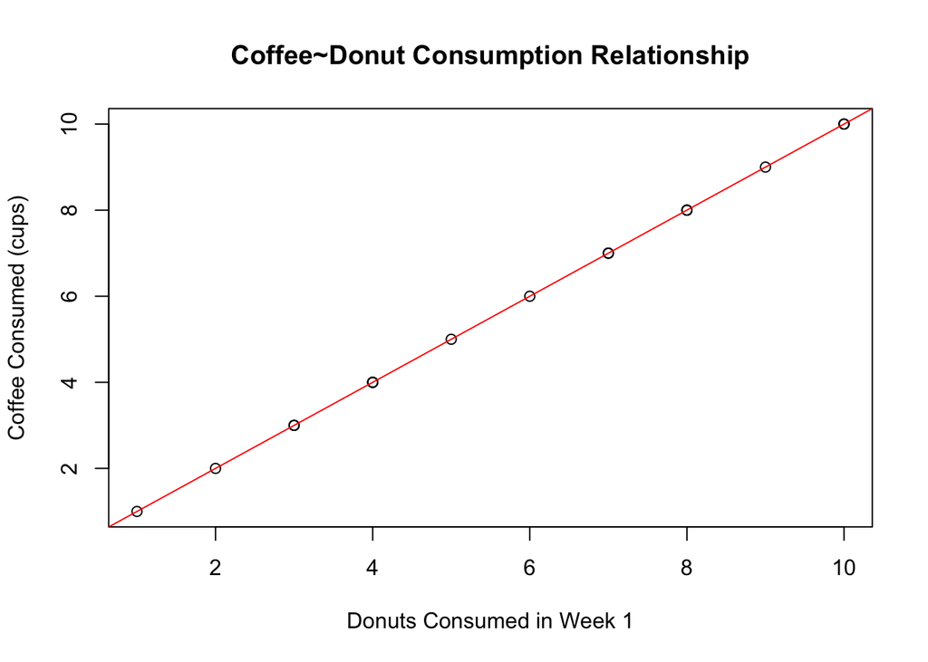

```r
plot(coffee_week1~donuts_week1,data=coffee_donut_data, main = "Coffee~Donut Consumption Relationship", ylab = "Coffee Consumed (cups)", xlab = "Donuts Consumed in Week 1")
abline(lm_coffee_donuts, col = "red")
```